# homework2

Karen Zhou

9/15/2020

We first need to import data

```r
library(tidyverse)
spider<-read_csv("spider.csv")
```

#Question 1 A) frequency histogram:

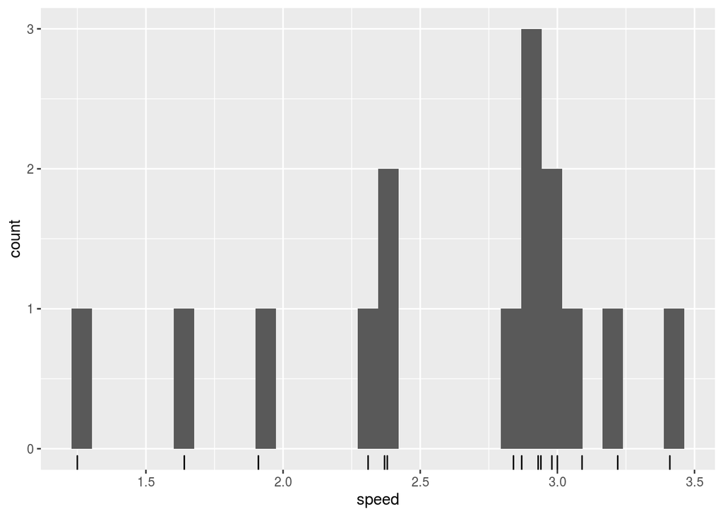

```r
ggplot(data = spider, aes(x = speed)) + geom_histogram() + geom_rug()
```

2. calculator: mean: 39.14/15 = 2.61 standard deviation: square root of .3817 = .6178

```r
spider %>%
  summarize(mean_speed= mean(speed), sd = sd(x = speed))
```

```
## # A tibble: 1 x 2
##   mean_speed    sd
##        <dbl> <dbl>
## 1       2.61 0.618
```

The mean and standard deviation calculated by hand and the ones calculated by R are the same.

The mean calculates the center, or average of the data, which the 2.61, while the standard deviation calculates the spread of the data, meaning that the typical data point is .6178 away from the mean.

3. From using the rules in the lecture, the first quartile: 2.31 the second quartile: 2.87 the third quartile: 3

```r
spider%>%
  summarize(
   q1 = quantile(speed,0.25),
    q2 = quantile(speed, 0.50),
    q3 = quantile(speed, 0.75))
```

```
## # A tibble: 1 x 3
##      q1    q2    q3
##   <dbl> <dbl> <dbl>
## 1  2.34  2.87  2.99
```

The answers are almost the same

4. Find the range, by using max - min, and the interquartile range of the data set, by using the iqr function

```r
spider%>%
  summarize(range = (max(x=speed) - min(x = speed)), iqr= IQR(x = speed ))
```

```
## # A tibble: 1 x 2
##   range   iqr
##   <dbl> <dbl>
## 1  2.16  0.65
```

The range is 2.16 and the IQR is 0.65

5. Boxplot

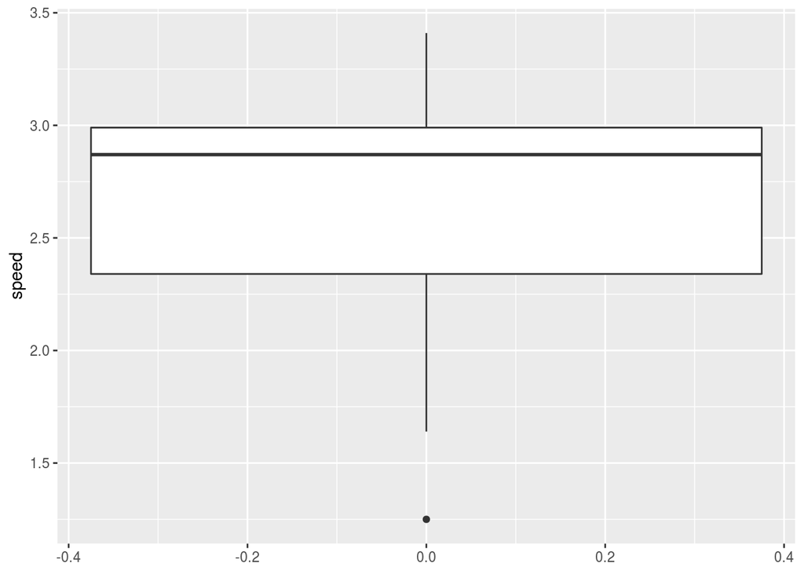

```r
ggplot(data = spider, aes(y = speed)) +geom_boxplot()
```

# Question 2